# 下一批 700 种编程语言The Next 700 Programming Languages

彼得·兰丁在 1966 年的论文中，把编程语言重新理解为一种表示法。这一观念转变，至今仍影响着我们如何设计工具、编写代码和组织系统。本文沿着这条线索，探讨领域专用语言（DSL）、框架、对象关系映射（ORM）、大语言模型（LLM），以及架构如何在我们不知不觉间悄然成形。Peter Landin’s 1966 paper reframed programming languages as notation — a shift that still shapes how we design tools, write code, and structure systems. This post follows that thread through DSLs, frameworks, ORMs, LLMs, and the quiet ways architecture takes shape without us noticing.

May 25, 2025 · 9 min · Oliver Daff

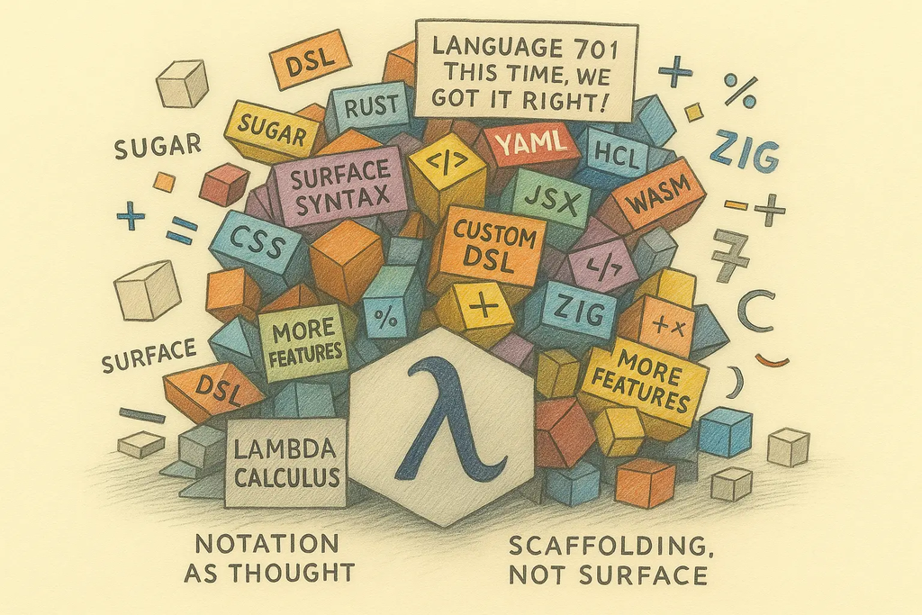

结构依然屹立——即使我们已经忘记了它赖以建立的根基The shape still holds — even when we forget what it’s built on

## 背景：一个由偶然催生的语言世界Setting the Stage: A World of Accidental Languages

在兰丁之前，编程语言与其说是经过设计的，不如说是自然而然冒出来的。Before Landin, programming languages weren’t really designed — they just happened.

你得面对硬件限制、交付期限，也许还有一位习惯使用穿孔卡片的数学教授。FORTRAN 帮工程师做计算，COBOL 让行政管理人员满意。至于 LISP？纯粹的理论，棱角分明。You had hardware constraints. A deadline. Maybe a maths professor with a punch card habit. FORTRAN helped engineers do maths. COBOL kept bureaucrats happy. LISP? Pure theory. Rough edges.

大多数语言迁就的是机器，而不是人的思维。语法只要能用就行，语义则靠默认的理解。早期的 FORTRAN 呢？数字、跳转、不言明的约定——代码与其说是在交谈，不如说是在念咒。Most languages bent to the machine, not the mind. Syntax was whatever worked. Semantics were implied. Early FORTRAN? Numbers, jumps, silent conventions — code more like incantation than conversation.

把语言看作一种*精心设计的产物*——其中有审慎的考量、明确的意图，甚至某种哲学——这样的观念，当时还没有真正扎根。The idea that a language could be a *designed object* — with care, intention, even philosophy — hadn’t quite landed.

兰丁看到了另一种可能。在他看来，代码不只是命令，而是*表示法*。表示法也不只是表面形式，它是显现出来的思想。既然它会塑造我们的思维方式，我们就需要认真对待它。Landin saw something different. To him, code wasn’t just commands — it was *notation*. And notation wasn’t just a surface. It was thought, made visible. And if it shaped how we think, it needed looking after.

他并不把语言仅仅看作操纵机器的工具，而是把它们看作推理的映照——支撑思考的脚手架。He didn’t see languages as mere tools for machines. He saw them as reflections of reasoning — scaffolding for thought.

转折就在这里：不是对语法小修小补，而是改变语言的目的。That was the turn. Not a tweak to syntax — a shift in purpose.

如果代码是我们表达思想的方式，那么设计上的选择就会开始塑造思考本身。而对兰丁来说，一切都始于一个更好的问题：If code is how we express thought, then design choices start to shape the thinking itself. And for Landin, it all started with a better question:

> 如果我们不再层层堆叠特性，而是从含义出发，会怎样？What if we stopped layering features, and started from meaning?

## ISWIM、λ 演算，以及少即是多的力量ISWIM, Lambda Calculus, and the Power of Less

兰丁不是在推销一门新语言。他追问的是：语言究竟是什么？Landin wasn’t pitching a new language. He was questioning what a language even is.

《下一批 700 种编程语言》的核心是一个大胆的想法：大多数语言，包括其中的循环、运算符和类型系统，都只是方便人使用的外层形式。它们下面有一个简单得多、却更强大的基础：**λ 演算**。只有变量、函数和替换，没有循环，没有类型，也没有副作用。可即便如此，它仍能表达图灵机所能表达的一切。At the heart of *The Next 700 Programming Languages* is a bold idea: that most languages — with their loops, operators, and type systems — are just ergonomic façades. Underneath it all lies something far simpler and more powerful: the **lambda calculus**. Just variables, functions, and substitution. No loops. No types. No side effects. And yet, it can express anything a Turing machine can.

对大多数人来说，λ 演算是一种理论；兰丁却把它视为根基。他问：*如果我们从这里开始呢？*不是为了施加限制，而是为了把事情弄清楚。To most, lambda calculus was theory. Landin saw it as foundation. He asked: *what if we started there?* Not to restrict, but to clarify.

他的回答是 **ISWIM**——一门构想中的语言，从未真正实现，却产生了深远影响。它存在的目的，是揭示那些潜藏的假设，而不是执行代码。His answer was **ISWIM** — a fictional language, never built, but deeply influential. It existed to expose assumptions, not to execute code.

ISWIM 把层层包装剥去，追问我们究竟需要什么。结果发现，大多数特性只是为了让使用过程更舒适。这些便利当然重要——但前提是，我们知道它们下面是什么。ISWIM stripped things back and asked what we really need. Turns out, most features are just there to make things more pleasant. And those conveniences matter — but only when we know what’s underneath.

也正是在这里，兰丁给了我们一个沿用至今的说法：**语法糖**。糖并不改变代码能做什么，而是改变使用它的感受。它让表面更顺滑，但有时也会遮住结构。That’s where Landin gave us a phrase we still use: **syntactic sugar**. Sugar doesn’t change what code can do. It changes how it feels. It smooths the surface — but sometimes, it also hides the structure.

## 当代码感觉很对时，问题也就来了When Code Feels Right (and That’s the Problem)

我们喜欢读起来清晰、流畅的代码，喜欢那种形式仿佛就贴合其所做之事的感觉。We like code that reads clean. That flows. That feels like the thing it’s doing.

这正是语法糖带来的东西：不是更强的能力，而是更轻松的使用体验。`a + b` 让人觉得是在做算术，其实它不过是换了一张更好看面孔的 `add(a, b)`。`obj.method(arg)` 也一样，不过是乔装打扮后的函数调用。还有那些看起来简单、却掩盖了递归或副作用的循环。这些糖衣让我们沉浸于流畅感，而流畅感往往会变成盲目的自信。That’s what syntactic sugar gives us — not power, just ease. `a + b` feels like arithmetic, but it’s just `add(a, b)` with a prettier face. Same with `obj.method(arg)` — function calls in disguise. Loops that look simple but mask recursion or side effects. These sugar coatings lull us into fluency, which often becomes false confidence.

| 代码Code | 它掩盖了什么What it hides |
| --- | --- |
| `for (i = 0; i < n; i++)` | 这是递归，只不过被展平了It’s recursion, just flattened |
| `obj.method(arg)` | 这是函数，只不过穿上了面向对象的外衣It’s a function, wearing OO clothes |
| `a + b` | 这是 `add(a, b)`，只不过更甜了It’s `add(a, b)`, but sweeter |

当清晰的外表掩盖了复杂性When clarity masks complexity

我们对看起来熟悉的代码一带而过，直到它以微妙的方式出错。因为一旦某种写法*感觉*易读，我们就不再追问它是否*正确*。We breeze past code that looks familiar — until it breaks in subtle ways. Because once something *feels* readable, we stop asking if it’s *true*.

这不只是语法糖的问题，也涉及大脑的工作方式。我们天生擅长补全空白、快速匹配模式。这在日常生活中很有用，在代码中却有风险，尤其是当语法诱使我们相信那些自己并未真正理解的东西时。This isn’t just about sugar. It’s about how our brains work. We’re wired to fill in blanks, to pattern-match fast. Great in real life. Risky in code. Especially when the syntax nudges us to trust what we haven’t really understood.

看看这段代码：Take this snippet:

```javascript
array.filter(x => x.active).map(x => x.id)
```

它给人的感觉很流畅，也很安全。可表面之下呢？关于空值、顺序和短路求值的隐含假设，都被整洁漂亮的外表遮住了。*看起来*显而易见的事，往往并不显然。It feels fluent. Feels safe. But under the hood? Implicit assumptions about nulls, ordering, short-circuiting — all papered over by a nice tidy surface. What *looks* obvious often isn’t.

ORM 是另一个典型例子。你写下 `user.posts`，感觉就像在访问一个字段。但这一行可能会触发一次查询，也可能触发十几次。它可能采用预加载、延迟加载，也可能悄无声息地引发连接结果爆炸。就这么一行，*看上去*是数据，实际表现却像是与远程系统订立的一份契约。ORMs are another classic case. You write `user.posts` and it feels like you’re accessing a field. But that one line might trigger a query, or a dozen. It might eager load, lazy load, or silently blow out to a join explosion. That one line? It *looks* like data — but behaves like a contract with a remote system.

表示法给人的感觉是本地操作。  
它的实际行为却完全不是。The notation feels local.  
The behaviour is anything but.

兰丁的洞见在于：表示法不只是装饰，而是脚手架。它若牢固，就能支撑我们的思考；它若扭曲，搭在上面的一切也会跟着变形。Landin’s insight was that notation isn’t just cosmetic. It’s scaffolding. If it’s solid, it holds our thinking. If it’s warped, everything we build on top bends with it.

## 工具的文化惯性The Cultural Inertia of Tools

语言塑造的不只是程序，也塑造人。Languages shape more than programs — they shape people.

一件工具用得足够久，就不再只是完成工作的手段，而会成为一种看待世界的方式。语法开始让人觉得像是真理，惯用法仿佛就是最佳实践，使用中的不顺手之处则变成了圈内人才懂的笑话。Use a tool long enough, and it becomes more than a way to get things done — it becomes a way of seeing. The syntax starts to feel like truth. The idioms feel like best practice. The friction points turn into inside jokes.

Perl 有自己的文化，Ruby 宣扬一种哲学，JavaScript 则演变成了一个四散发展的庞大社群。Perl had a culture. Ruby preached a philosophy. JavaScript turned into a diaspora.

这正是兰丁预见到的转变。如果语言是表示法，而表示法塑造思想，那么语言设计就不只是技术问题，也是社会学问题。它决定团队如何沟通、优先优化什么、传授什么、遗忘什么。语法只是起点。从包管理器到代码检查规则，一切都会成为人们日常使用体验的一部分。That’s the shift Landin anticipated. If language is notation, and notation shapes thought, then language design isn’t just technical — it’s sociological. It determines how teams communicate, what they optimise for, what gets taught, what gets forgotten. Syntax is just the start. Everything from package managers to lint rules becomes part of the lived experience.

图中文字：工具有用，所以我们采用它（Tool is useful / We adopt it）→ 反复使用成为默认选择，我们再次拿起它（Repetition becomes default / We reach for it again）→ 它感觉很直观，所以想必是对的（It feels intuitive / So it must be right）。接着，一条路径是：改变让人觉得不对劲，即便存在更好的选择（Change feels wrong / Even when better options exist），于是又回到采用原来的工具；另一条路径是：我们不再质疑，它成为第二天性（We stop questioning / It becomes second nature）。图题：工具如何变成信念（How tools become beliefs）。

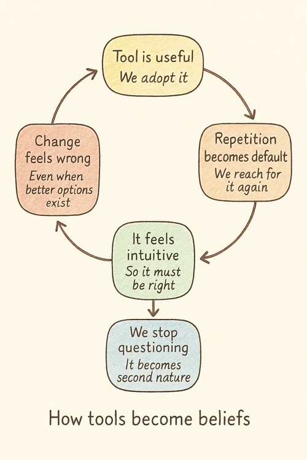

工具如何变成信念How tools become beliefs

大多数语言的成功，并不是因为它们的设计最好，而是因为它们建立了习惯、社群和默认做法。一旦这些形成，改变就开始让人觉得是在破坏规则——即便那些规则从一开始就没有道理。Most languages don’t succeed because they’re the best design. They succeed because they build habits, communities, and defaults. And once those are in place, change starts to feel like breaking the rules — even if the rules never made sense in the first place.

这就是工具的文化代价。它们编码的不只是逻辑，还有价值观。That’s the cultural cost of tools. They don’t just encode logic. They encode values.

## DSL、LLM，以及接下来的 700 种错误DSLs, LLMs, and the Next 700 Mistakes

我们并没有停止发明语言，只是把这件事藏得更隐蔽了。We didn’t stop inventing languages. We just got sneakier about it.

如今，它们就藏在眼前：基础设施中的 YAML、资源配置中的 HCL、数据流水线中那些“类似 SQL”的配置。它们披着数据的外衣，于是我们把它们当成无害的标记。可一旦打开，里面尽是分支逻辑、副作用、神奇的默认值，还有恳求下一位开发者什么都别动的注释。Now they hide in plain sight — YAML for infrastructure, HCL for provisioning, “SQL-ish” configs for data pipelines. They wear the costume of data, so we treat them like harmless markup. But open one up, and it’s all branching logic, side effects, magical defaults, and comments pleading with the next developer not to touch anything.

它们并非天生有问题，但也确实不是以易于理解为目标构建的。其中大多数更看重写起来快，而不是长期便于推理。它们甜美、宽容——直到某一刻突然不再如此。They’re not inherently broken. But they weren’t exactly built to be understood. Most of them favour quick writing over long-term reasoning. They’re sugary and forgiving — right up until they’re not.

就在我们刚开始摸清它们的门道时，LLM 又加入进来。现在，人工合成的 DSL 可以按需生成：配置看似像模像样，结构却像棉花糖一样不堪一击。代码读起来没问题，直到你试着运行，才发现某些东西悄无声息地消失了。And just when we started to get a handle on them, LLMs entered the party. Now we’ve got synthetic DSLs being generated on demand — plausible-looking configs with the structural integrity of fairy floss. The code reads fine, until you try to run it and something silently disappears.

真正的问题不在于 DSL 有多少，而在于我们多么轻率地假装它们不是语言：没有明确的语义，没有规范，只有良好的愿望和制表符间距。The real issue isn’t the number of DSLs. It’s how casually we pretend they’re not languages — no semantics, no spec, just good intentions and tab spacing.

它们看起来不像代码，行为却与代码无异：有结构、有副作用、有规则，也有意外。正因为它们像数据，我们往往没有给予它们真正的语言所需要的那份审慎。They don’t look like code, but they act like it — with structure, side effects, rules, and surprises. Because they resemble data, we often don’t give them the care real languages demand.

它们会像代码一样出错。  
它们也像代码一样，需要认真设计。They fail like code.  
They demand design like code.

兰丁并没有号召大家追求极简主义。他只是希望我们认真对待语言，把语言设计当回事——因为它确实重要。Landin didn’t call for minimalism. He just wanted us to take language seriously — to design it like it mattered, because it does.

## 可组合性：系统设计的超能力Compositionality as a Systems Superpower

尽管讨论中满是语法，兰丁真正关心的却是形态——表面之下的结构。For all the talk of syntax, Landin’s real focus was shape — the structure beneath the surface.

ISWIM 不是为了令人惊艳而构想的，而是为了让各部分形成稳固的整体。它很小，没错，但足够坚实，可以在上面继续构建而不致坍塌。它甚至不必成为一门真正的语言，只要是一个足够稳固、可供继续构建的基础就够了。ISWIM wasn’t built to impress. It was built to hold together. Small, yes. But sturdy enough to build on without it collapsing. It never needed to be a language — just something solid enough to build on.

这就是可组合性带来的东西：在压力下依然稳定的设计。这样的系统允许你增加一个部件，而不必重写其余部分；理解会不断积累，而不是逐渐瓦解。That’s what compositionality gives you: designs that stay stable under pressure. Systems where you can add one piece without rewriting the rest. Where understanding grows instead of unravels.

你一定见过这样的例子：UNIX 管道、HTML 与 CSS、React 组件、Terraform 模块。You’ve seen it: UNIX pipes. HTML and CSS. React components. Terraform modules.

它们并非完美无缺，但几十年过去，依然屹立。They weren’t flawless. But decades later, they’re still standing.

脆弱的又是哪些？通常是那些很巧妙的设计。  
确实很巧妙——直到你试着扩展它们的那一刻。The fragile ones? Usually the clever ones.  
Clever, sure — right up to the moment you try to extend it.

可组合的系统经得起时间考验，因为各个部件不会互相掣肘。你可以替换其中一块，而不必重新理解整个系统。边界依然清晰，头脑也不至于一团乱麻。Compositional systems age well because the pieces don’t fight. You can replace a chunk without relearning the whole. Boundaries stay intact. Brains stay sane.

这才是 ISWIM 真正留下的遗产：不是极简，而是*形态*。That was ISWIM’s real legacy — not minimalism, but *shape*.

> 可以层层搭建的原语。  
> 是边缘能够对齐的积木，而不是一团团没有定形的东西。Primitives that stacked.  
> Bricks with edges you can align — not amorphous blobs.

## 第 701 种语言The 701st Language

我们很容易期待下一门语言：语法更清爽，更少让人搬起石头砸自己脚的陷阱，既顺手又不碍事。也许这一次，抽象终于靠得住了；也许各个层次不会再泄漏底层细节。It’s easy to want the next one. A cleaner syntax. Fewer footguns. Something that feels right without getting in the way. Maybe this time the abstractions will hold. Maybe the layers won’t leak.

但兰丁真正关心的从来不是这个。他并不是在追求更清爽的工具，而是在追问工具如何塑造我们的思维方式。他从表示法出发，但这个想法触及的层面更深。我们如何设计 API、塑造架构、划定边界，其中都能看到它的影子。But that was never really Landin’s focus. He wasn’t chasing cleaner tools — he was tracing how tools shape the way we think. He started with notation, but the idea runs deeper. You can see it in how we design APIs, shape architectures, set boundaries.

每一种选择都有自己的引力。有些把我们拉向流畅感：写得快、容易上手，却难以质疑。另一些则把我们拉向结构：也许慢一点，但更容易扩展，也更值得信赖。Every choice has a gravity to it. Some pull toward fluency — fast to write, easy to adopt, hard to question. Others pull toward structure — slower, maybe, but easier to extend, easier to trust.

兰丁给我们的不是模板，而是一种视角：看清什么时候是默认做法在牵着我们走，并在设计时始终想着结构。所求不只是优雅，更是经久耐用。Landin didn’t give us a template. He gave us a lens — to see when the defaults are steering us, and to design with shape in mind. Not just for elegance. For endurance.

为了让系统在不断生长时，依然清晰可读。For systems that stay legible as they grow.